# R code for Figure 4 - figure supplement 2 - heatmaps of comparative analysis

Xiao Xu (xxu@rockefeller.edu)

June 2018

Xu X, Stoyanova EI, Lemiesz A, Xing J, Mash DC, Heintz N (2018). Species and Cell-Type Properties of Classically Defined Human and Rodent Neurons and Glia.

Specifically, this workflow will generate the heatmaps accompanying IGV tracks.

Load libraries and functions:

```r
# source custom functions
source("functions.R")
# libraries for heatmaps and colors
library(RColorBrewer)
library(gplots)
# library for manipulating data
library(data.table)
# work in the tidyverse
library(tidyverse)
```

## Heatmap to accompany IGV tracks

Import rpkms for mouse and human from figure 3

```r
rpkms_mouse <- read_rds("../data_clean/figure_3_main_rpkms_mouse.RDS")
rpkms_human <- read_rds("../data_clean/figure_3_main_rpkms_human.RDS")
rpkms_mouse_granule <- rpkms_mouse[, grepl("granule", colnames(rpkms_mouse))]
rpkms_human_granule <- rpkms_human[, grepl("granule", colnames(rpkms_human))]
```

Import mean rpkm coverage from ATAC tracks over promoters

```r
atac <- read_tsv("../data/atac_prom_rpkm_mean.txt") %>%
  select(Gene, contains("granule")) %>%
  rename(Human = Human_granule, Mouse = Mouse_granule) %>%
  column_to_rownames("Gene") %>%
  as.matrix()
```

```
Setting row names on a tibble is deprecated.
```

Genes to visualize

```r
igv_genes <- c("Gapdh", "Etv1",
               "Clvs2", "Vwc2",
               "Cnksr3", "Ece1")
igv_genes_2 <- c("Pde1a", "Pde1c")
rpkms_for_igv_mouse <- rpkms_mouse_granule[igv_genes, ] %>% t()
rpkms_for_igv_human <- rpkms_human_granule[igv_genes, ] %>% t()
rpkms_for_igv_mouse_2 <- rpkms_mouse_granule[igv_genes_2, ] %>% t()
rpkms_for_igv_human_2 <- rpkms_human_granule[igv_genes_2, ] %>% t()
atac_for_igv <- atac[igv_genes, ] %>% t()
atac_for_igv_2 <- atac[igv_genes_2, ] %>% t()
```

Specify colors for heatmap

```r
# palette for rpkms
cor_col <- colorRampPalette( brewer.pal(9, 'YlOrRd') )(100)
cor_breaks <- seq(-2, 10, length.out = 101)
cor_breaks_atac <- seq(-2, 5, length.out = 101)
sidebar_col <- rep(c("black", "grey70", "grey30"), each = 2)
sidebar_col_2 <- c("grey70", "grey30")
sidebar_row_m <- rep("blue", 3)
sidebar_row_h <- rep("red", 2)
sidebar_row_atac <- c("red", "blue")
```

Function for heatmap plotting

```r
plotExpHeatmap <- function(mat, cor_col, cor_breaks, sidebar_row,
                           sidebar_col, outfile) {
  pdf(outfile, width = 11, height = 8.5)
  hm <- heatmap.2(
    mat,
    dendrogram = "none", Rowv = FALSE, Colv = FALSE, # no dendrogram, no reordering
    col = cor_col, breaks = cor_breaks,  # colors for values
    RowSideColors = sidebar_row, ColSideColors = sidebar_col,  # sidebar
    scale = "none", trace = "none",
    key.title = NA, key.ylab = NA,
    cexRow = 1, cexCol = 1, margins = c(2, 2),
    labCol = FALSE, labRow = FALSE, symkey = F,
    keysize = 1, key.par = list(mar = c(4, 2, 1, 1))
  )
  dev.off()

  # and display in this file
  eval(hm$call)
}
```

Plot heatmap mouse

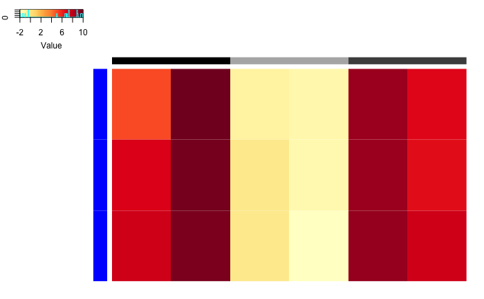

```r
plotExpHeatmap(rpkms_for_igv_mouse, cor_col, cor_breaks,
               sidebar_row_m, sidebar_col,
               "../figures/figure_4_s2_heatmap_for_igv_mouse.pdf")
```

Plot heatmap human

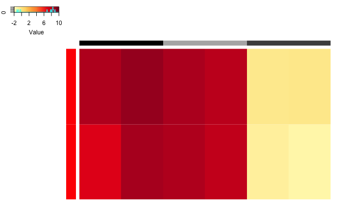

```r
plotExpHeatmap(rpkms_for_igv_human, cor_col, cor_breaks,
               sidebar_row_h, sidebar_col,
               "../figures/figure_4_s2_heatmap_for_igv_human.pdf")
```

Plot heatmap for mouse and human ATAC

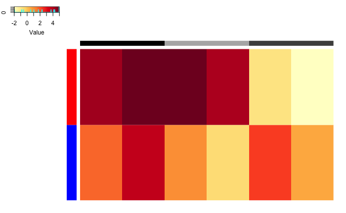

```r
plotExpHeatmap(atac_for_igv, cor_col, cor_breaks_atac,
               sidebar_row_atac, sidebar_col,
               "../figures/figure_4_s2_heatmap_for_igv_atac.pdf")
```

Plot heatmap mouse for pde1a and pde1c

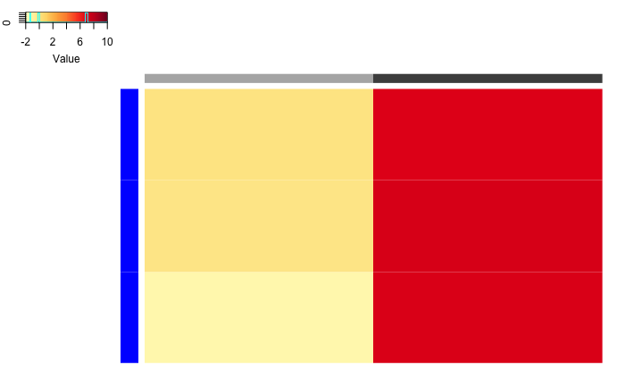

```r
plotExpHeatmap(rpkms_for_igv_mouse_2, cor_col, cor_breaks,
               sidebar_row_m, sidebar_col_2,
               "../figures/figure_4_s2_heatmap_for_igv_pde_mouse.pdf")
```

Plot heatmap human for pde1a and pde1c

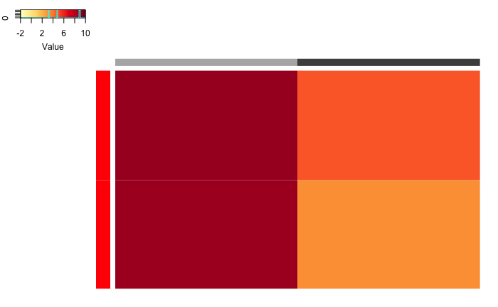

```r
plotExpHeatmap(rpkms_for_igv_human_2, cor_col, cor_breaks,
               sidebar_row_h, sidebar_col_2,
               "../figures/figure_4_s2_heatmap_for_igv_pde_human.pdf")
```

Plot heatmap for mouse and human ATAC for pde1a and pde1c

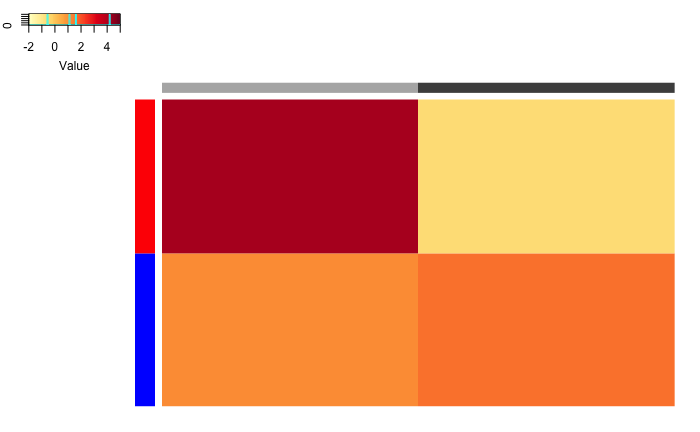

```r
plotExpHeatmap(atac_for_igv_2, cor_col, cor_breaks_atac,
               sidebar_row_atac, sidebar_col_2,
               "../figures/figure_4_s2_heatmap_for_igv_pde_atac.pdf")
```

### GATA family genes

Genes to visualize

```r
igv_genes <- c("Trps1", "Gata1", "Gata2", "Gata3", "Gata4", "Gata5", "Gata6")
rpkms_for_igv_mouse <- rpkms_mouse[igv_genes, ] %>% t()
rpkms_for_igv_human <- rpkms_human[igv_genes, ] %>% t()
```

Specify colors for heatmap

```r
# palette for rpkms
cor_col <- colorRampPalette( brewer.pal(9, 'YlOrRd') )(100)
cor_breaks <- seq(-2, 7, length.out = 101)
cell_type_cols <- c(
  Granule = "#33A02C",
  Basket = "#FF6600",
  Astrocyte = "#0033FF",
  Oligo = "#00CCCC",
  OPC = "#00FFFF"
)
sidebar_col <- rep("grey50", length(igv_genes))
sidebar_row_m <- rep(cell_type_cols, c(3, 3, 2, 2, 2))
sidebar_row_h <- rep(cell_type_cols, each = 2)
```

Plot heatmap mouse

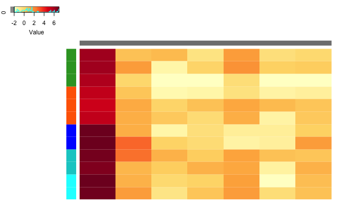

```r
plotExpHeatmap(rpkms_for_igv_mouse, cor_col, cor_breaks,
               sidebar_row_m, sidebar_col,
               "../figures/figure_4_s2_heatmap_for_igv_gata_mouse.pdf")
```

Plot heatmap human

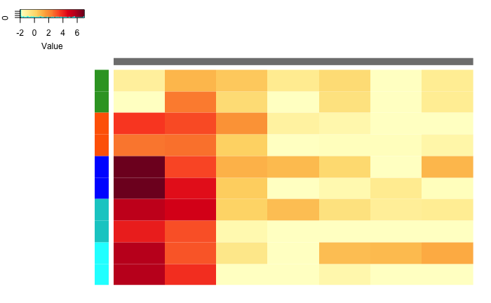

```r
plotExpHeatmap(rpkms_for_igv_human, cor_col, cor_breaks,
               sidebar_row_h, sidebar_col,
               "../figures/figure_4_s2_heatmap_for_igv_gata_human.pdf")
```

For Figure 4, get some numbers to quantify expression and ATAC coverage for Jkamp and Rtn1

```r
genes <- c("Jkamp", "Rtn1")
# mouse
rpkms_mouse[genes, grepl("granule|basket", colnames(rpkms_mouse))] %>%
  t() %>%
  as.data.frame() %>%
  mutate(Cell_type = rep(c("Granule", "Basket"), each = 3)) %>%
  mutate(Species = "Mouse") %>%
  rbind(
    rpkms_human[genes, grepl("granule|basket", colnames(rpkms_human))] %>%
      t() %>%
      as.data.frame() %>%
      mutate(Cell_type = rep(c("Granule", "Basket"), each = 2)) %>%
      mutate(Species = "Human")
  ) %>%
  gather(key = "Gene", value = "Exp", -c("Cell_type", "Species")) %>%
  group_by(Cell_type, Gene, Species) %>%
  summarise(Mean = mean(Exp)) %>%
  spread(key = Species, value = Mean)
```

| Cell_type | Gene | Human | Mouse |
| --- | --- | --- | --- |
| Basket | Jkamp | 4.829716 | 6.916644 |
| Basket | Rtn1 | 5.385868 | 7.353026 |
| Granule | Jkamp | 8.630895 | 6.267942 |
| Granule | Rtn1 | 7.615805 | 8.135075 |

```r
atac[genes, ]
```

```
         Human    Mouse
Jkamp 3.812462 1.721855
Rtn1  2.837418 2.592087
```

## SNP analysis

Download SNP data from NHGRI-EBI SNP catalog (https://www.ebi.ac.uk/gwas/docs/file-downloads, Downloaded August 16, 2018) and process for intersecting with peaks.

Import snps. Clean up column names.

```r
nhgri <- read_tsv("../data/gwas_catalog_v1.0.2-associations_e93_r2018-08-14.tsv")
colnames(nhgri) <- make.names( tolower( colnames(nhgri) ), unique = TRUE )
```

Filter for SNPs with dbGAP IDs and that have chromosome information. Select distinct entries by ID, study, and disease

```r
nhgri_clean <- nhgri %>%
  mutate(dbGAP = ifelse(grepl("^rs", snps, perl = TRUE),
                        TRUE, FALSE)) %>%
  filter(dbGAP) %>%
  drop_na(chr_id, chr_pos) %>%
  distinct(snps, pubmedid, disease.trait, .keep_all = TRUE) %>%
  select(-dbGAP)
```

Identify SNPs that are associated with a trait in two or more studies.

```r
multiple <- nhgri_clean %>%
  mutate(snp_disease = paste(snps, disease.trait, sep = "_")) %>%
  group_by(snp_disease) %>%
  filter(n() > 1) %>%
  pull(snps)
```

Output file for intersecting.

```r
write_tsv(nhgri_clean %>%
            select(snps, disease.trait, chr_id, chr_pos) %>%
            distinct(snps, .keep_all = TRUE),
          "../output/snps_nhgri.txt")
```

Read in overlapped files, annotate, and output. How many distinct SNPs and traits are there?

```r
lapply(
  c("all", "da"),
  function(x)
    lapply(
      c("granule", "basket"),
      function(ct) {
        filename <- paste("../data/snps_human_", ct, "_", x, ".txt", sep = "")
        peaks <- fread(filename, select = c(1:2, 4, 6:8),
                       col.names = c("snp_chr", "snp_pos", "snp",
                                     "peak_chr", "peak_start", "peak_end")) %>%
          as.tibble()
        peaks_annot <- peaks %>%
          left_join(nhgri_clean %>%
                      select(snp = snps, disease.trait, pubmedid, reported.gene.s.,
                             mapped_gene, strongest.snp.risk.allele, context,
                             risk.allele.frequency, p.value, study.accession),
                    by = "snp") %>%
          mutate(Multiple = ifelse(snp %in% multiple, TRUE, FALSE)) %>%
          arrange(desc(Multiple))
        outfile <- paste("../output/figure_4_s2_snps_human", ct, x, "annot.txt", sep = "_")
        write_tsv(peaks_annot, outfile)
        return(
          tibble(
            n_SNPs = peaks_annot %>% distinct(snp) %>% nrow,
            n_traits = peaks_annot %>% distinct(disease.trait) %>% nrow
          )
        )
      }
    )
)
```

```
[[1]]
[[1]][[1]]
```

| n_SNPs | n_traits |
| --- | --- |
| 767 | 475 |

```
[[1]][[2]]
```

| n_SNPs | n_traits |
| --- | --- |
| 1381 | 704 |

```
[[2]]
[[2]][[1]]
```

| n_SNPs | n_traits |
| --- | --- |
| 163 | 164 |

```
[[2]][[2]]
```

| n_SNPs | n_traits |
| --- | --- |
| 363 | 289 |

```
NANA
```